# Shark Attack Species Data

Sam Fisher

April 30, 2016

SCRAP THIS CODE CHUNK

SCRAP THIS CODE CHUNK

SCRAP THIS CODE CHUNK…

#### Load the Data

```r
## ---- Load the data
dat <- read_csv("Shark_Attack_Data_4-7-2016.csv",col_names=TRUE,n_max=5897) #5897=last good row
dat[24] <- NULL #remove null rows and repeated 'Case Number' rows
dat[23] <- NULL
dat[21] <- NULL
dat[20] <- NULL

# Rename the 'Case Number' column
colnames(dat)[1] <- "CaseNumber"
# Rename the 'Fatal (Y/N)' column
colnames(dat)[13] <- "Fatal"
```

#### Clean the data

```r
## ---- Clean the data

# Remove duplicate entries
species_dat <- dat %>% filter(!duplicated(CaseNumber))

# Standardize the encoding of the Species, Activity, Fatal, and Type columns
species_dat <- species_dat %>%
  mutate(Species=iconv(Species,from="CP1252",to="UTF-8"),
         Fatal=iconv(Fatal,from="CP1252",to="UTF-8"))

# standardize the character cases of Species column to lower; Fatal to uppercase
species_dat <- species_dat %>%
  mutate(Species=stri_trans_tolower(Species),
         Fatal=stri_trans_toupper(Fatal))
```

## Wrangle the Species column

The Species variable provides textual descriptions of the species of shark reported in the shark attack. The descriptions are free form. In addition to possibly including the **type of shark**, many entries include its **size** (length and/or weight range), **gender**, and other miscellaneous information. Therefore, the Species variable needs to be wrangled, or normalized, so that the shark types can be parsed and extracted. As the additional information contained in a Species entry may be useful for downstream processing and analysis, it is also wrangled and used to create additional variables, e.g., length, weight, and gender.

Note, only 2991 of 5880 reported incidents contain information about shark species.

#### Normalize the Species descriptions

General normalization…

```r
## Normalize all Species column entries

# Remove NA's and only keep CaseNumber,Species, and Fatal columns
species_dat <- species_dat %>% filter(!is.na(Species)) %>%
  select(CaseNumber,Species,Fatal)
```

BEGIN TESTING POS_TAGS

END TESTING POS_TAGS

```r
# Remove dates from Species entries
species_dat <- species_dat %>% filter(!is.na(Species)) %>%
  mutate(Species=gsub("([0-9]{1,2}\\/[0-9]{1,2}\\/[0-9]{4})"," ",Species))
# Remove annoying unicode characters
#species_dat <- species_dat %>% filter(!is.na(Species)) %>%
#  mutate(Species=gsub("(\u393C|\u3E33|\u613C|\u3E30|\u3E34|\u623C|\u3E64|\uFFFD)","",Species))

## Remove all double quotes at the beginning and end of each Species entry
species_dat <- species_dat %>% filter(!is.na(Species)) %>%
  mutate(Species=gsub(pattern="(^|[\\s])[\"]"," ",Species), #from beginning  “
         #Species=gsub(pattern="([^0-9])([\"])([\\S]|$)","\\1",Species)) #ending (unless preceded by a digit)
         Species=gsub(pattern="([\"])([a-z -]+)([\"])","\\2",Species),
         Species=gsub(pattern="([a-z -]+)([\"])","\\1",Species))

species_dat <- species_dat %>% filter(!is.na(Species)) %>% #Remove unnecessary punctuation
  mutate(Species=gsub(pattern="([a-zA-Z])[\\.]","\\1 ",Species), #removes word-final periods
         Species=gsub(pattern="\\?+"," ",Species), #removes question marks
         Species=gsub(pattern="[,;:]"," ",Species), #removes commas & semicolons
         Species=gsub(pattern="\\[|\\]"," ",Species), #removes square brackets
         Species=gsub(pattern="\\(|\\)"," ",Species)) #, #remove parentheses
         #Species=gsub(pattern="([e])[\"][\\s]","\\1 ",Species)) #strange double quote won't go away.

#normalize shark size descriptions
species_dat <- species_dat %>% filter(!is.na(Species)) %>%
  mutate(Species=gsub(pattern="pound","lb",Species), #pound to lb
    Species=gsub(pattern="(\\d)(\\s|-)(metre|m|meter|cm|ft|feet|foot|kg|lb|lbs)(\\s|$)","\\1\\3 ",Species),
         Species=gsub(pattern="(\\d)(?-)(ft|feet|foot)(\\s|$)","\\1' ",Species),
         Species=gsub(pattern="(\\d)(?-)(meter|metre)(\\s|$)","\\1m ",Species))

species_dat <- species_dat %>% filter(!is.na(Species)) %>%
  mutate(Species=gsub(pattern="(\\w)(\\s|-)(tipped)(\\s|$|\")","\\1tip ",Species), #normalizes tipped to tip
         Species=gsub(pattern="(\\w)(\\s|-)(finned)(\\s|$|\")","\\1fin ",Species),
         Species=gsub(pattern="(sharks|sharkk|shar k|shar ;)","shark",Species), # normalize 'shark'
         #Species=gsub(pattern="( shar)\\s+([^k])"," shark \\2",Species), # normalize 'shark'

         Species=gsub(pattern="(\\d)(')(shark)","\\1\\2 \\3",Species), #5'shark to 5' shark
         Species=gsub(pattern=" (\")(\\w)"," \\2",Species), #turns "word into word
         Species=gsub(pattern="(fragment|wobbegong|day|pointer)(s)","\\1",Species), #plural to singular
         Species=gsub(pattern=" & "," and ",Species), # & to and
         Species=gsub(pattern="zambezi","zambesi",Species), #zambesi
         Species=gsub(pattern="grey","gray",Species), #gray
         Species=gsub(pattern="(seven gill|seven-gill|7-gill)","sevengill",Species), # sevengill
         Species=gsub(pattern="(sandtiger|sand-tiger)","sand tiger",Species), # sand tiger
         Species=gsub(pattern="(nosed)","nose",Species), # broadnose, ..nose
         Species=gsub(pattern="(blac[^k])","black",Species),
         Species=gsub(pattern="(blackip)","blacktip",Species),
         Species=gsub(pattern="limbatus","blacktip",Species),
         Species=gsub(pattern="blackfin","blacktip",Species),
         Species=gsub(pattern="whtietip","whitetip",Species),
         Species=gsub(pattern="galapgos","galapagos",Species),
         Species=gsub(pattern="(bonit[oa])","mako",Species,perl=TRUE),
         Species=gsub(pattern="(bronze whale )","bronze whaler",Species,perl=TRUE),
         Species=gsub(pattern="carchari","carcharhi",Species,perl=TRUE),
         Species=gsub(pattern="tawney","tawny",Species,perl=TRUE),
         Species=gsub(pattern="leucas","bull",Species,perl=TRUE),
         Species=gsub(pattern="obscurus","dusky",Species,perl=TRUE),
         Species=gsub(pattern="albimarginatus","silvertip",Species,perl=TRUE),
         Species=gsub(pattern="maculpinnis|maculipinnis","spinner",Species,perl=TRUE),
         Species=gsub(pattern="whalershark","whaler shark",Species,perl=TRUE),
         Species=gsub(pattern="sandshark","sand shark",Species,perl=TRUE)
  )

species_dat <- species_dat %>% #filter(!is.na(Species)) %>%
  mutate(Species=gsub(pattern="(blue|broad|black|shovel)([\\s-]+)(nose|fin)","\\1\\3",Species,perl=TRUE))

species_dat <- species_dat %>% filter(!is.na(Species)) %>%
  mutate(Species=gsub(pattern="cat shark","catshark",Species))

species_dat <- species_dat %>% filter(!is.na(Species)) %>%
  mutate(Species=gsub("(not confirmed|not cofirmed)","unconfirmed",Species))

species_dat <- species_dat %>% filter(!is.na(Species)) %>%
  mutate(Species=gsub("(not authenticated)","unauthenticated",Species))

species_dat <- species_dat %>% filter(!is.na(Species)) %>%
  mutate(Species=gsub("(gr[ea]y|brown)[-]?(colored)","\\1",Species,perl=TRUE))

#Remove stop words from entries
#species_dat <- species_dat %>% filter(!is.na(Species)) %>%
#  mutate(Species=gsub("(^|\\s)(another|been|a|as|an|by|of|or|on|that|his|but|it|its|their|than|from|have|out|were|be|is|was|later|on|with|and|the|')($|\\s)"," ",Species))
species_dat <- species_dat %>% filter(!is.na(Species)) %>%
  mutate(Species=gsub("(^|\\s)(another|been|a|as|an|by|of|or|on|that|his|but|it|its|their|than|from|have|out|were|be|is|was|later|on|with|and|the)($|\\s)"," ",Species))

species_dat <- species_dat %>% filter(!is.na(Species)) %>%
  mutate(Species=gsub(pattern="\\s+"," ",Species)) #Reduce multiple spaces to 1 space

#species_dat %>% filter(!is.na(Species)) %>% select(Species) %>% View()
#species_dat$Species[675]
```

The following word clouds illustrate the textual information contained in the Species column.

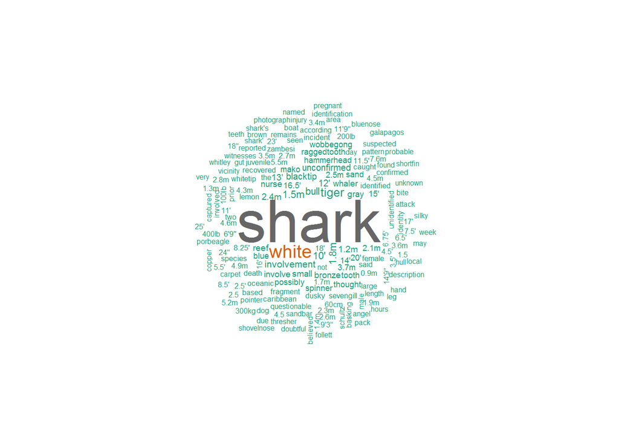

```
## Leaving out the most frequent word 'shark'...
```

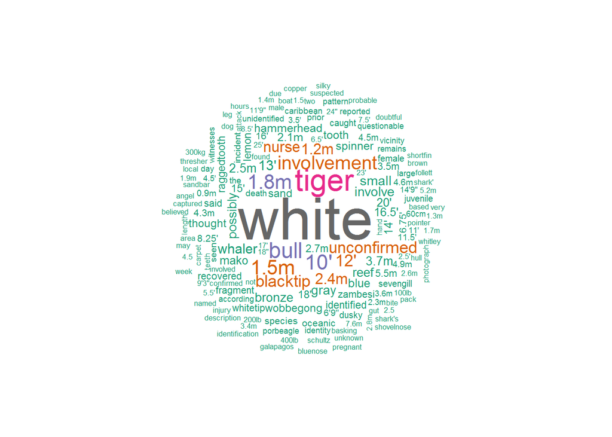

SCRAP THE FOLLOWING CODE CHUNK?..

As illustrated, further wrangling is needed. The word clouds show a variety of information that is not in itself categorically coherent.

## Extracting from the Species Column

After exploring, normalizing, analyzing, and visualizing the species entry descriptions, the next step is to extract the three categories. Let’s extract the Species descriptions into three distinct categories: (1) Shark Type, describing the type of shark; (2) Size, describing the size of the shark; and (3) Gender.

#### Shark Type (aka Species)

Here, we’ll add a new column (variable) containing textual descriptions of the species of shark in an attack.

Extract Species categories…

```r
species_labeled <- species_dat %>% filter(!is.na(Species)) %>%
  mutate(shark_modifier=ifelse(grepl("(shark)",Species),
                               str_extract(Species,"([a-z][a-z]+)([\\s-]?shark)"),NA)
         ,shark_modifier2=ifelse(grepl("(shark)",Species),
                               str_extract(Species,"([a-z][a-z]+[\\s-])([a-z]+[\\s-]?)(shark)"),NA)
         ,shark_modifier2=ifelse(!is.na(shark_modifier) & !is.na(shark_modifier2),
                                 str_trim(str_extract(shark_modifier2,"^([a-z]+[\\s-])")),shark_modifier2)
         ,shark_modifier=ifelse(
           grepl("(spinner|blacktip)",shark_modifier) & grepl("(spinner|blacktip)",shark_modifier2),
           "spinner shark",shark_modifier)

         ,shark_modifier=ifelse(
           grepl("(thresher|blue)",shark_modifier) & grepl("(thresher|blue)",shark_modifier2),
           "thresher shark",shark_modifier)

         ,shark_modifier2=ifelse(
           grepl("^(cm|to|kg|lb|in|the|old|auth|likel|belie|thin|partial|incide|clark|remains|aka|may|slim|very|female|barrac|shark|dead|great|gaffed|large|numero|thresh|cold|proba|spinner|possib|whaler|photograph|identi|recov|small|juvenile|little)",
                 shark_modifier2,perl=TRUE),
           NA,shark_modifier2)

      ,shark_modifier=ifelse(
           grepl("^(lg|lb|kg|cm|been|carlsmith|description|female|for|gaffed|juvenile|large|larger|little|media|mouth|number|pack|recovered|remains|reported|same|saw|school|several|shark|small|two|the|unidentified|shot|young)([\\s])",
                 shark_modifier,perl=TRUE),
           NA,shark_modifier)

      ,shark_modifier=gsub("( shark)$","",shark_modifier)

      ,species_cat=ifelse(!is.na(shark_modifier) & !is.na(shark_modifier2),
                          paste(shark_modifier2,shark_modifier,sep=" "),
                          ifelse(!is.na(shark_modifier),shark_modifier,NA)

                          )

      ,species_cat=gsub(" colo[u]?red","",species_cat,perl=TRUE)

      ,species_cat=gsub("([\\s]|^)(fragment|those|belly|bonnethed|scalloped|spotted|shot|sixgill|six|this|unknown|may)([\\s]|$)",
                        "",species_cat,perl=TRUE)

      ,species_cat=gsub("blacktip spinner","spinner",species_cat,perl=TRUE)

      ,species_cat=gsub("dog","catshark",species_cat,perl=TRUE)

      ,species_cat=gsub("^(not)$","no",species_cat,perl=TRUE)

      ,species_cat=ifelse(species_cat=="no","no shark",species_cat)
      ,species_cat=ifelse(species_cat=="oceanic white","white",species_cat)
      ,species_cat=ifelse(species_cat=="oceanic species","white",species_cat)

      ,species_cat=gsub("(porbeagle)[\\s]+(mako|white)","\\2",species_cat,perl=TRUE)

      ,species_cat=ifelse(species_cat=="",NA,species_cat)
         ) %>% select(CaseNumber,species_cat)
```

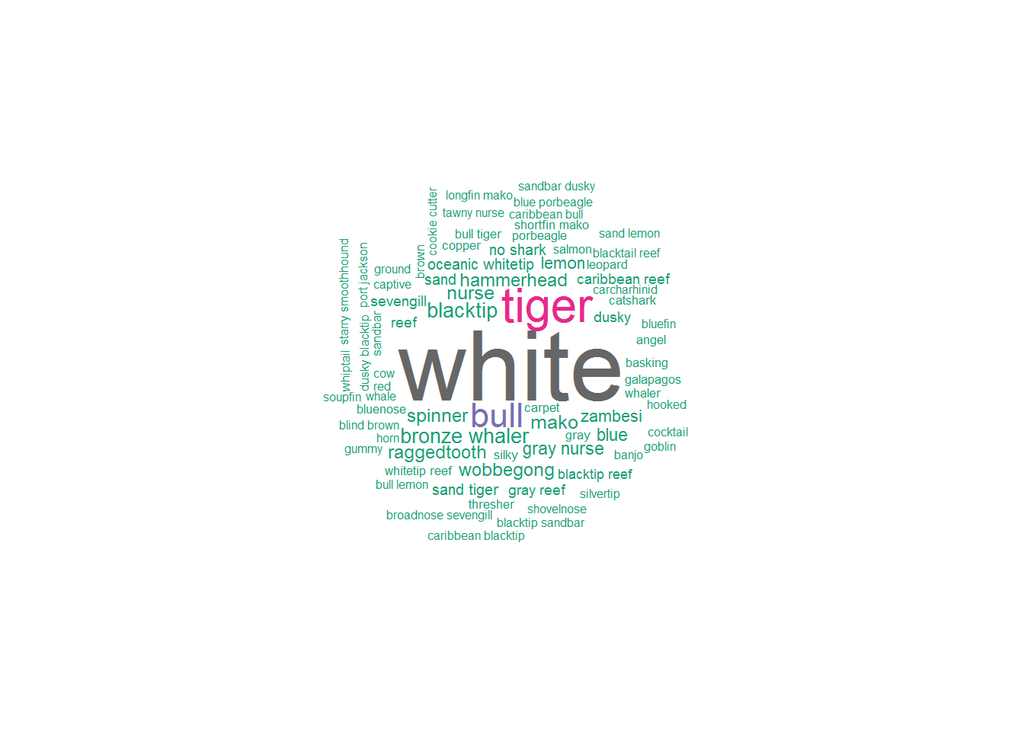

```r
## ---- Visualize the Species categories
species_labels <- species_labeled %>% filter(!is.na(species_cat)) %>% group_by(species_cat) %>%
  summarize(attacks=n()) %>% arrange(desc(attacks)) %>% select(species_cat,attacks)

wordcloud(species_labels$species_cat,species_labels$attacks,min.freq = 1,#c(4,1),
          random.order=FALSE,
          colors=brewer.pal(8, "Dark2"))
```

Write Species categories to CSV file…

```r
## ---- Write Species Categories to CSV
#write.csv(species_labeled,"species_labeled.csv",row.names = FALSE, quote = FALSE)
```

Plot species categores by frequency…

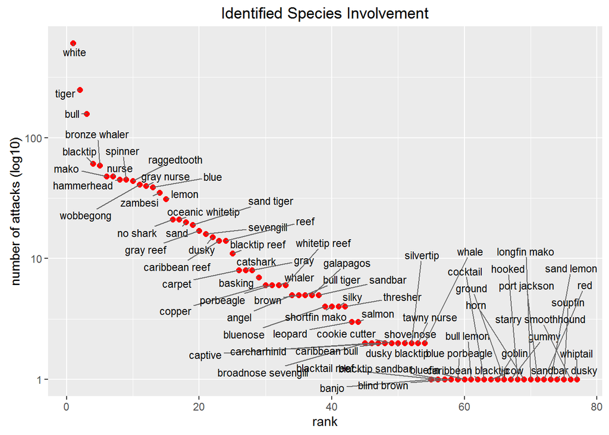

```r
p <- cbind(r=seq(1,nrow(species_labels)),species_labels) %>%
  ggplot(aes(r,attacks, label = species_cat)) +
  ylab("number of attacks (log10)") + xlab("rank") + ggtitle("Identified Species Involvement")
p + scale_y_log10() + scale_x_continuous() + geom_point(size=2,color="red") +
  geom_text_repel(cex=3)
```

Plot species to fatalities…

```r
## ---- Species to Fatalities
species_fatal <- left_join(species_labeled,species_dat,by="CaseNumber") %>%
  filter(!is.na(Fatal), !is.na(species_cat)) %>% select(species_cat,Fatal) %>% group_by(species_cat) %>%
  summarize(attacks=n(),fatalities=sum(Fatal=="Y"),pct_fatal=round(fatalities/attacks*100,2))

## Stratify?
## Remove biases
# Discount where frequency is super low, but pct_fatal is super high, e.g. freq=1,pct_fatal=100
```

Known species with fatal attacks…

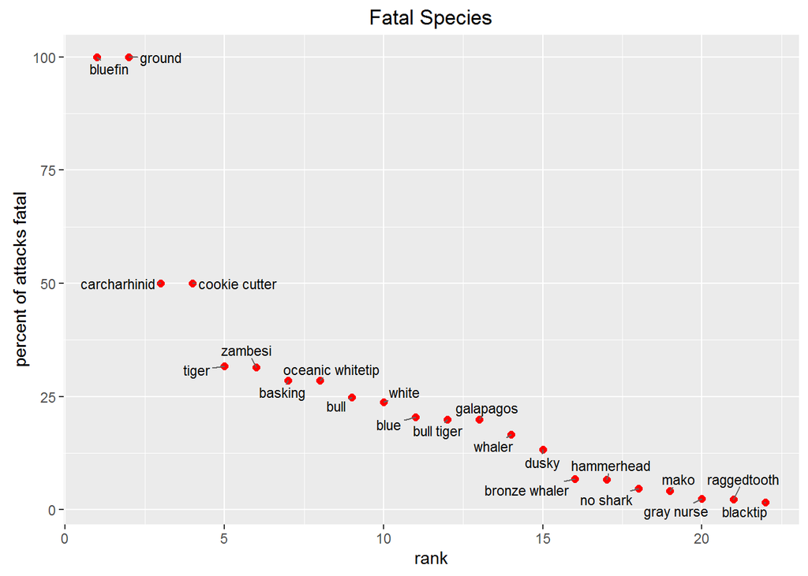

```r
## ---- get species with fatal attacks
most_fatal_species <- species_fatal %>% filter(pct_fatal>0) %>% arrange(desc(pct_fatal),attacks)

## ---- plot most fatal species
p <- most_fatal_species %>%
  cbind(r=seq(1,nrow(most_fatal_species)),most_fatal_species) %>% #filter(Freq>freq_cutoff) %>%
  ggplot(aes(r,pct_fatal, label = species_cat)) +
  ylab("percent of attacks fatal") + xlab("rank") + ggtitle("Fatal Species")
p + scale_x_continuous() + geom_point(size=2,color="red") +
  geom_text_repel(cex=3)
```

Known species with zero fatal attacks…

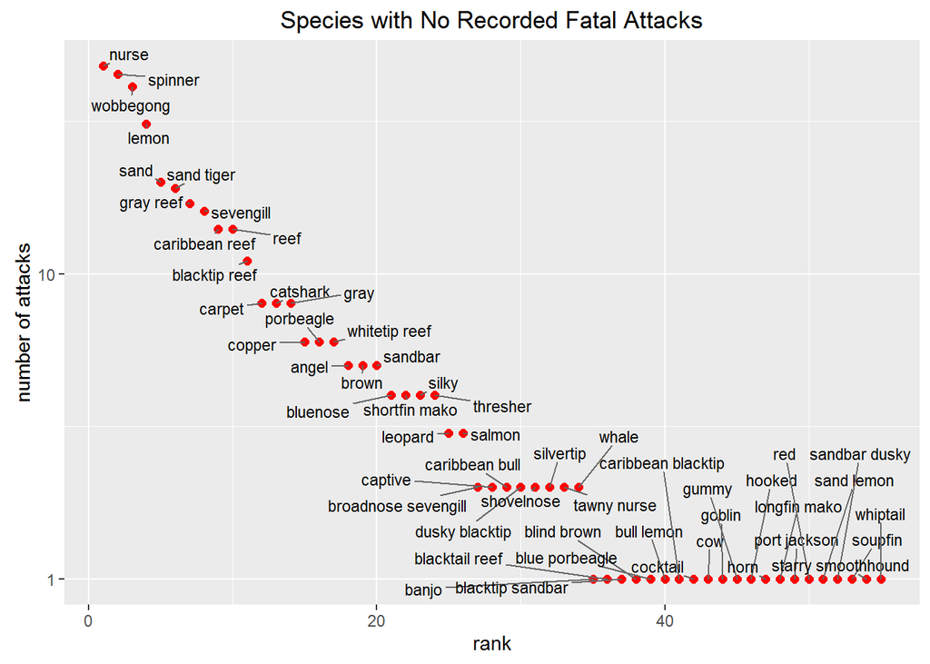

```r
## ---- get non-fatal species
non_fatal_attack_species <- species_fatal %>% filter(pct_fatal==0) %>% arrange(desc(attacks),pct_fatal)

## ---- plot non-fatal species
p <- non_fatal_attack_species %>%
  cbind(r=seq(1,nrow(non_fatal_attack_species)),non_fatal_attack_species) %>% #filter(Freq>freq_cutoff) %>%
  ggplot(aes(r,attacks, label = species_cat)) +
  ylab("number of attacks") + xlab("rank") + ggtitle("Species with No Recorded Fatal Attacks")
p + scale_y_log10() + scale_x_continuous() + geom_point(size=2,color="red") +
  geom_text_repel(cex=3)
```

#### Shark Size

```r
feet_pattern <- c("([\\d\\.]+)(\')")
inches_pattern <- c("([\\d\\.]+)(\")")
meters_pattern <- c("([\\d\\.]+)(m)")
cm_pattern <- c("([\\d\\.]+)(cm)")
kg_pattern <- c("([\\d\\.]+)(kg)")
lb_pattern <- c("([\\d\\.]+)(lb)")

size_dat <- species_dat %>%
  mutate(feet=as.numeric(gsub("\'","",stri_extract_last_regex(Species,feet_pattern))),
         inches=as.numeric(gsub("\"","",stri_extract_last_regex(Species,inches_pattern))),
         meters=as.numeric(gsub("m","",stri_extract_last_regex(Species,meters_pattern))),
         cm=as.numeric(gsub("cm","",stri_extract_last_regex(Species,cm_pattern))),
         kg=as.numeric(gsub("kg","",stri_extract_last_regex(Species,kg_pattern))),
         lb=as.numeric(gsub("lb","",stri_extract_last_regex(Species,lb_pattern)))
  )

size_dat <- size_dat %>%
  mutate(feet=ifelse(!is.na(feet)&!is.na(inches),
                       feet+(inches/12), # combine feet+inches into feet
                     ifelse(is.na(feet)&!is.na(inches),
                            inches/12,feet)),
         meters=ifelse(is.na(meters)&!is.na(feet),feet*0.3048, # 1ft = 0.3048m
                       ifelse(!is.na(cm),cm/100,meters)),
         kg=ifelse(is.na(kg)&!is.na(lb),lb*0.453592,kg) # lb to kg ~ 1 to 0.453592

  ) %>% select(-inches,-cm,-lb)

#write.csv(size_dat,"shark_size.csv",row.names = FALSE,quote=FALSE)

summary(size_dat$meters) #%>% kable(caption='Length Summary (meters)')
```

```
##    Min. 1st Qu.  Median    Mean 3rd Qu.    Max.    NA's
##  0.2032  1.5240  2.4000  2.7120  3.6580 10.0600    1084
```

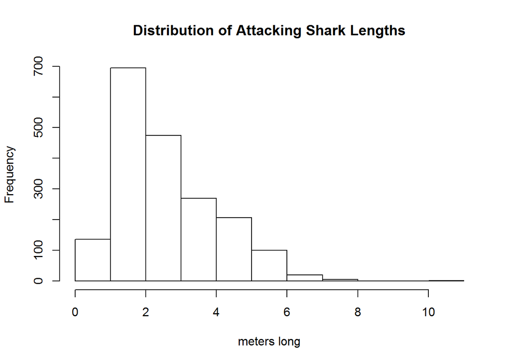

```r
hist(size_dat$meters,main="Distribution of Attacking Shark Lengths",xlab = "meters long")
```

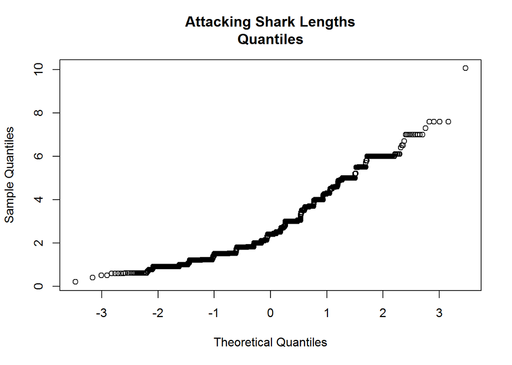

```r
qqnorm(size_dat$meters,main="Attacking Shark Lengths\nQuantiles")
```

```r
summary(size_dat$kg) #%>% kable(caption='Weight Summary (kg)')
```

```
##     Min.  1st Qu.   Median     Mean  3rd Qu.     Max.     NA's
##    3.629   79.690  140.000  239.800  274.600 3500.000     2876
```

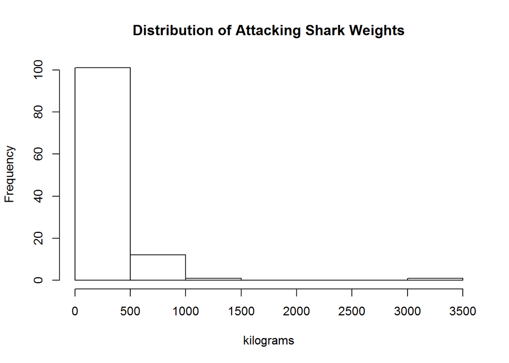

```r
hist(size_dat$kg,main="Distribution of Attacking Shark Weights",xlab = "kilograms")
```

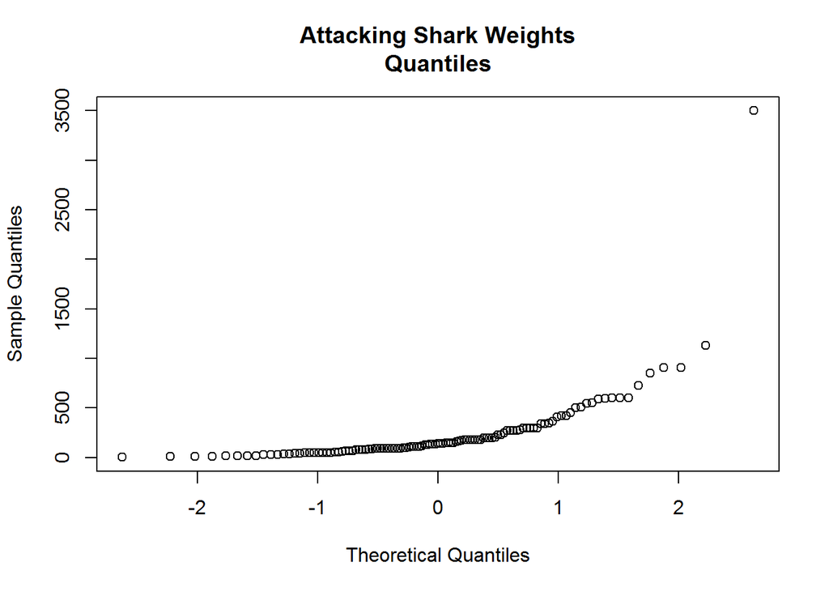

```r
qqnorm(size_dat$kg,main="Attacking Shark Weights\nQuantiles")
```

#### Shark Gender

```r
## ---- get Shark Gender data
gender_dat <- species_dat %>%
  mutate(Species=gsub("(pregnant)","female",Species),
         gender=ifelse(grepl("(female)",Species),
                       "female",
                       ifelse(grepl("male",Species),
                              "male",
                              NA))
         ) %>% filter(!is.na(gender))

#write.csv(gender_dat,"shark_gender.csv",row.names = FALSE,quote=FALSE)
fatal_by_gender <- gender_dat %>% group_by(gender) %>%
  summarize(attacks=n(),fatalities=sum(as.numeric(Fatal=="Y")),pct_fatal=round(fatalities/attacks*100,2))

fatal_by_gender %>% kable
```

| gender | attacks | fatalities | pct_fatal |
| --- | --- | --- | --- |
| female | 22 | 7 | 31.82 |
| male | 8 | 0 | 0.00 |